# Markov chain Monte Carlo sampling algorithms

Lecture 3

Dr Samuel Livingstone

# Last time

- Recap on Bayesian inference
  $$\pi(\theta|y) \propto \pi_0(\theta)f(y|\theta)$$
- General state space Markov chains and ergodic averages
  $$\begin{aligned}
  X_{i+1}|X_i \sim &P(X_i,\cdot), ~~~ \lim_{n\to\infty}\| P^n(x,\cdot)
  - \pi \|_{TV} = 0,\\ &\frac{1}{n}\sum_{i=1}^nf(X_i) \approx
  \mathbb{E}_\pi[f].
  \end{aligned}$$

# Outline

- Quick recap from last time
- Markov chain Monte Carlo
  - The (Random Walk) Metropolis algorithm
  - The (General) Metropolis–Hastings algorithm
  - Gibbs sampler
  - A case study (if time)

# Part 1: Recap

# Markov chains on general state spaces

- Key object is the transition kernel:
  $$P: E \times \mathcal{E} \to [0,1]$$
- For every $x \in E$, $P(x,\cdot)$ is the distribution for the next state, given that the current state is $x$. I.e.
  $$P(x,A) := \mathbb{P}(X_{i+1} \in A|X_i = x).$$

# Limiting distributions

- If a Markov chain $P$ is $\pi$-irreducible, aperiodic and $\pi$-invariant, then $\pi$ is the unique limiting distribution.
- **$\pi$-irreducible:** any event $A$ s.t. $\pi(A) > 0$ has a chance of being visited
- **Aperiodic** means the chain doesn’t cycle through disjoint regions periodically
- **$\pi$-invariant** if $X_i \sim \pi \implies X_{i+1} \sim \pi$

# Recap of $\pi$-invariance

- Key fact: If $X_n \sim \mu$, then the (marginal) distribution of $X_{n+1}$ is given by
  $$\mathbb{P}(X_{n+1} \in A) = \int P(x,A)\mu(dx)$$
- $\pi$ is **invariant** for $P$ if for any $A \in \mathcal{E}$
  $$\pi(A) = \int P(x,A)\pi(dx)$$
- If $P$ is **$\pi$-reversible**, then it is $\pi$-invariant
  $$\pi(dx)P(x,dy) = \pi(dy)P(y,dx)$$
- Note, however, that Markov chains can be $\pi$-invariant without being $\pi$-reversible

# Part 2: MCMC & the (random walk) Metropolis algorithm

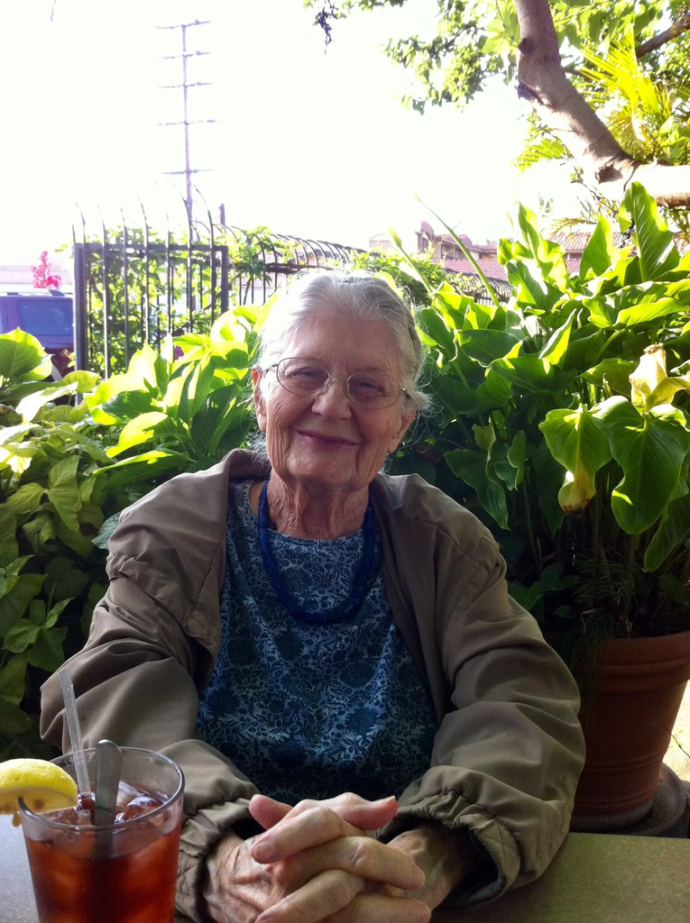

# Basic idea of MCMC

- **Goal:** compute $\mathbb{E}_\pi[f]$, with only $c\pi$ known
- **Approach:**
  - Construct a Markov chain
    $$\{X_t\}_{t\geq 0}$$
    s.t. $\pi$ is the limiting distribution
  - Compute ergodic averages
    $$\frac{1}{n} \sum_{i=0}^{n-1} f(X_i) \approx \mathbb{E}_\pi[f].$$
- **But how can this be done??**

# The Metropolis–Hastings algorithm: background

- Almost all MCMC methods in use today are either a particular case of the Metropolis–Hastings algorithm or can be derived from it in some way
- First introduced in 1953 by Metropolis, Rosenbluth, Rosenbluth, Teller & Teller
- General algorithm published in 1970 by Hastings
- Only really became popular in Statistics in the 1990s (when computers got powerful enough)
- Sparked a **Markov chain Monte Carlo revolution**, as Bayesian inference finally became usable
- The algorithm is now ranked among the top 10 of the 20th century (throughout all of science)!

# The original Metropolis, Rosenbluth, Rosenbluth, Teller & Teller (1953) paper

[figure not shown]

# Idea of the (random walk) Metropolis algorithm

- Based on the familiar ‘accept-reject’ principle
- First we will propose a new candidate state for the Markov chain
- Then, we use some information about $\pi$ to decide whether or not to ‘accept’ the candidate state
- If we do not accept, the chain stays put

# Random Walk Metropolis algorithm

- (Assume $\pi$ has a density (or mass function in discrete case))
- For $i \in \{0,...,n-1\}$
  - Draw $\xi_i \sim N(0,1)$ and set $Y = X_i + h\xi_i$
  - Draw $U \sim \mathcal{U}[0,1]$ and compute
    $$\alpha(X_i,Y) = \min\left(1, \frac{\pi(Y)}{\pi(X_i)} \right)$$
  - Set
    $$X_{i+1} = \begin{cases}
    Y \qquad U \leq \alpha(X_i,Y) \\
    X_i \qquad \text{otherwise}
    \end{cases}$$
- Output the Markov chain $\{X_1,...,X_n\}$.
- **Question.** Why does this work when only $c\pi$ is known?

# A detour: the Random Walk

- A random walk is a very simple Markov chain
  $$X_{i+1} = X_i + \xi_{i+1},$$
  $\xi_{i+1} \sim N(0,\sigma^2)$ (for example).
- It is well-studied and easy to simulate
- The transition density is given by
  $$q(x,y) = \frac{1}{\sqrt{2\pi\sigma^2}}\exp\left\{
  -\frac{1}{2\sigma^2}(y-x)^2\right\}$$
- Note that $q(x,y) = q(y,x)$
- **Questions.** 1. How is this Markov chain used in the random walk Metropolis algorithm? 2. What measure is the random walk reversible with respect to?

# Some discussion…

- The acceptance rate has an intuitive interpretation
  $$\pi(Y) \geq \pi(X_i) \implies \text{Accept the move!}$$
- *Uphill* moves are always accepted, downhill moves are sometimes rejected
- This means that the Markov chain spends more time in regions of higher probability under $\pi$

# Stepping through an example

*Show demo code*

# Sketch proof of $\pi$-invariance

- Suppose that $y \neq x$ is proposed and then accepted.
- The density associated with this is
  $$q(x,y)\min\left( 1, \frac{\pi(y)}{\pi(x)}\right)$$
  where $q(x,y)$ is the random walk transition density
- The detailed balanced equations are
  $$\pi(x)q(x,y)\min\left(1,\frac{\pi(y)}{\pi(x)}\right) =
  \pi(y)q(y,x)\min\left(1,\frac{\pi(x)}{\pi(y)}\right)$$
- Here this reduces to
  $$\pi(x)\min\left(1,\frac{\pi(y)}{\pi(x)}\right) = \pi(y)\min\left(1,
  \frac{\pi(x)}{\pi(y)}\right)$$
  - **Question.** Why?
- Both sides are the same and equal to $\min(\pi(y),\pi(x))$, so detailed balance holds

# RWM example, $\pi$ is $N(0,1)$, $X_0 = 0$

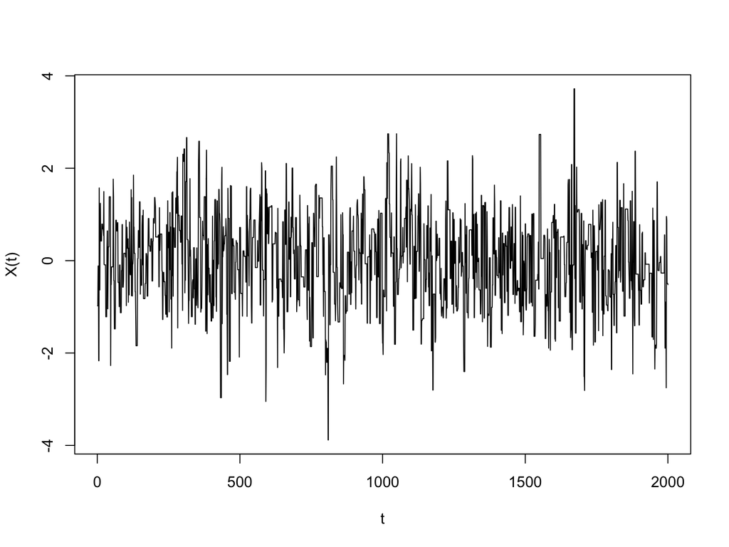

# Constructing an ergodic average

For example:

```r
sum( (-2 < mc$x_store) * (mc$x_store < 2) * 1 ) / nits
```

```
## [1] 0.9475
```

is an approximation for the integral:
$$\int \mathbb{I}_{(-2,2)}(x) \frac{1}{\sqrt{2\pi}}e^{-x^2/2}dx.$$

To approximate $\mathbb{E}_\pi[X]$ we can compute

```r
mean(mc$x_store)
```

```
## [1] 0.009321799
```

- **Question.** What are the true numbers we are estimating here given that $\pi$ is $N(0,1)$?

# Running average plot for the mean estimate

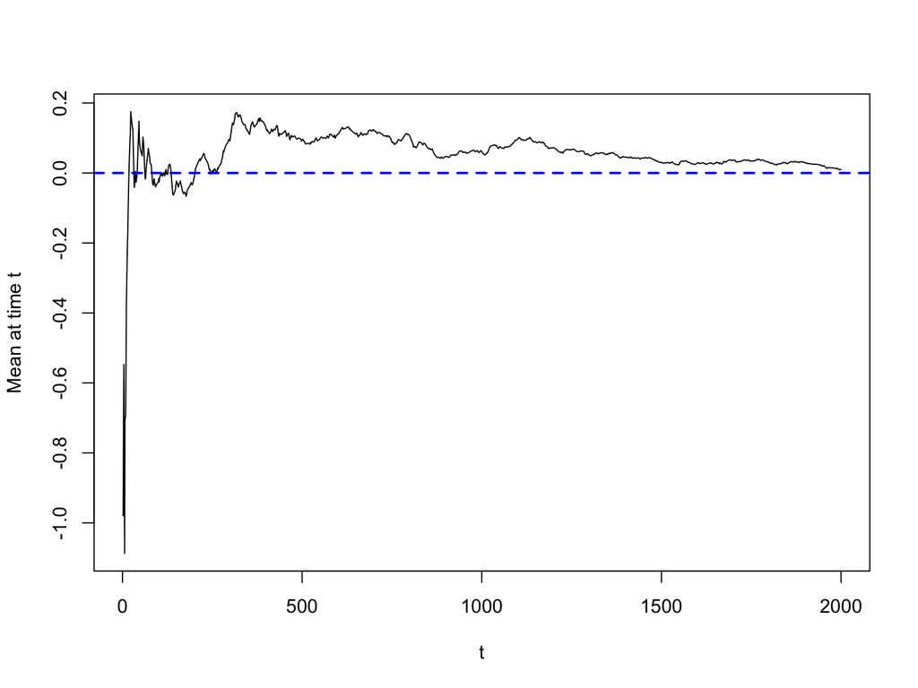

# The (average) acceptance rate

```r
cat("The acceptance rate is: ",mc$a_rate)
```

```
## The acceptance rate is:  0.4705
```

- An important indicator of algorithm performance

# What happens when the step-size is too large?

- Random Walk proposals are *blind* in some sense (don’t use any information about $\pi$ to construct candidate move)
- So if $h$ is too large, then it is likely that $\pi(Y) \ll \pi(X_i)$, meaning
  $$\alpha(X_i,Y) = \min\left(1, \frac{\pi(Y)}{\pi(X_i)} \right) \approx 0.$$
- This will mean very few proposals are accepted and the chain won’t move much.

# Choosing $h$ too large example

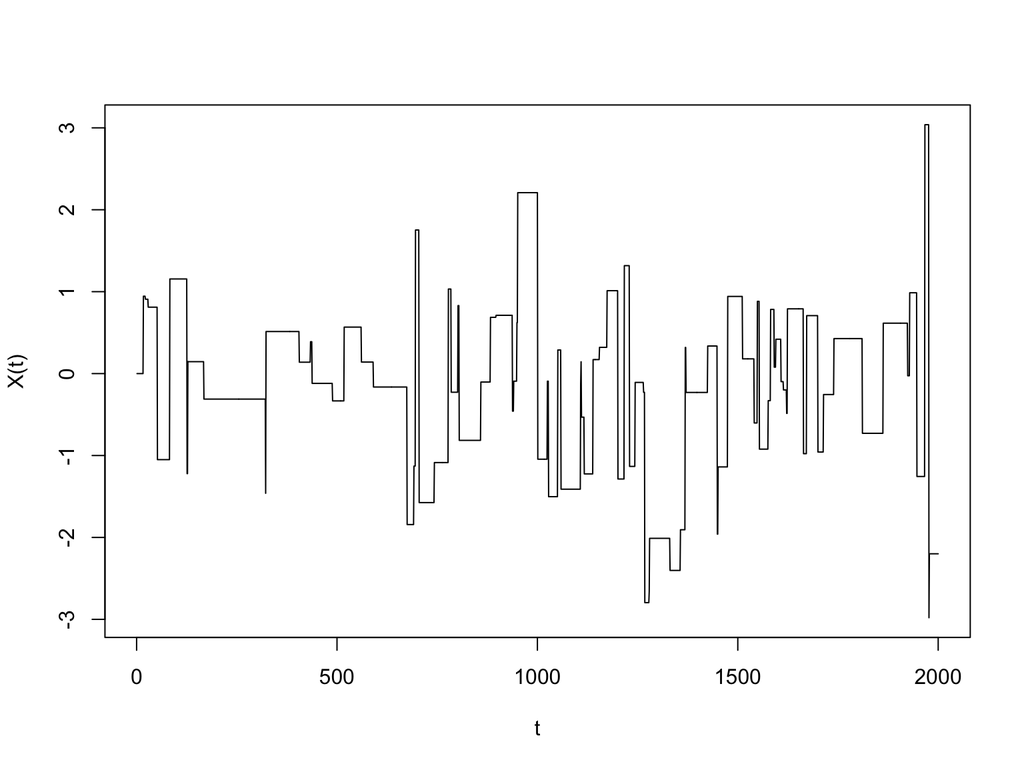

```
## The acceptance rate is:  0.043
```

# What about when it’s too small?

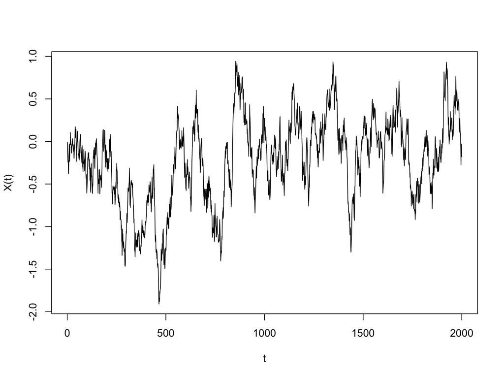

```
## The acceptance rate is:  0.9835
```

# The Goldilocks principle

- There is a **sweet spot** ($h$ not too big or small)
- In 1D the optimal acceptance rate is typically around 44%
- In the high dimensional settings it is around **23%**
- Guidelines are based on interesting probabilistic limiting arguments
  - We relate Markov chains to a limiting *diffusion* process and then optimise the *speed* of this diffusion
  - We will most likely not explore this further, but see e.g. Roberts & Rosenthal (2001)

# Quick questions

- What is the difference between the following expressions ($U$, $X_i$ and $Y$ defined as above)?
  $$\begin{aligned}
  (1)& ~ U \leq \min\left( 1, \frac{\pi(Y)}{\pi(X_i)}\right) \\
  (2)& ~ U \leq \pi(Y)/\pi(X_i) \\
  (3)& ~ \log(U) \leq \log\pi(Y) - \log\pi(X_i)
  \end{aligned}$$
- What is the probability of any of the above expressions ($U \sim \mathcal{U}[0,1]$, fixed $X_i$ and $Y$)? How would you prove it?
- Which would we prefer to implement on a computer?

# Part 3: Metropolis–Hastings

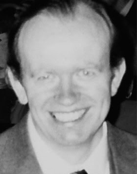

# Metropolis-Hastings algorithm: general case (assuming $\pi$ has a density)

For $i \in \{1,...,n-1\}$

- Draw $Y \sim Q(X_i,\cdot)$
- Draw $U \sim \mathcal{U}[0,1]$, compute
  $$\alpha(X_i,Y) = \min\left(1,
  \frac{\pi(Y)q(Y,X_i)}{\pi(X_i)q(X_i,Y)}\right).$$
- Set
  $$X_{i+1} = \begin{cases}
  Y \qquad U \leq \alpha(X_i,Y) \\
  X_i \qquad \text{otherwise}
  \end{cases}$$
- Output the Markov chain $\{X_1,...,X_n\}$.
- **Question.** *How are $Q$ and $q$ related?*

# Some discussion…

- In the random walk case the acceptance rate has an intuitive interpretation
  $$\pi(Y) \geq \pi(X_i) \implies \text{Accept the move!}$$
- This is because the proposal is symmetric, meaning $q(y,x) = q(x,y)$
  - Recall $e^{-(y-x)^2/2} = e^{-(x-y)^2/2}$ in Gaussian case
- In the general case this intuition is lost, but nonetheless choosing a different form of proposal can be advantageous

# Some other popular choices for proposals in Metropolis-Hastings

- **The Independence Sampler.** $Y \sim Q(\cdot)$
  - Here the proposal is independent of the current state $X_i$
  - Easy to implement and analyse, but often performs poorly when $d$ large
- **Component-wise updates/Metropolis-within-Gibbs.** Only update some components of the state at each iteration (e.g. a single dimension)
  - A classic example is the *Gibbs sampler*
- **Gradient-based algorithms.**. State-of-the-art for continuous and smooth targets
  - Use $\nabla \log\pi(x)$ within the proposal somehow
  - We will look at these in lecture 5
  - Classic examples: Langevin algorithms (e.g. MALA), Hamiltonian Monte Carlo (HMC)

# Theorem: Metropolis–Hastings works!

*The following hold for a Markov chain produced using the Metropolis-Hastings algorithm:*

1. *The chain is $\pi$-invariant.*
2. *$\pi$ is the unique limiting distribution if $\infty > \pi(x) > 0$ and $\infty > q(x,y) > 0$ for all $x,y \in E$*

# Proof sketch, part 1

- Consider $y \neq x$ is proposed and then accepted. Density associated with this is
  $$q(x,y)\alpha(x,y).$$
- Using the above we can show $\pi$-reversibility, since.
  $$\begin{aligned}
  \pi(x)q(x,y)\alpha(x,y) &= \pi(x)q(x,y) \min \left(1,
  \frac{\pi(y)q(y,x)}{\pi(x)q(x,y)}\right) \\
  &=
  \min\left( \pi(x)q(x,y), \pi(y)q(y,x) \right) \\
  &=
  \pi(y)q(y,x) \min \left(\frac{\pi(x)q(x,y)}{\pi(y)q(y,x)}, 1 \right) \\
  &= \pi(y)q(y,x)\alpha(y,x).
  \end{aligned}$$

# Proof of part 2

- Note that the conditions imply
  $$q(x,y)\alpha(x,y) > 0$$
  for all $x,y \in E$.
- This means that for any $A \in \mathcal{E}$
  $$\int_A \pi(y)dy > 0 \implies \int_A q(x,y)\alpha(x,y)dy > 0,$$
  and hence the chain is $\pi$-irreducible.
- It also implies aperiodicity by setting $A$ to be any set that includes the current state $x$
- **Remark.** Conditions are sufficient but not necessary.

# Towards a more general algorithm & proof

- To move beyond densities/mass functions, we can construct the Radon–Nikodym derivative
  $$\rho(x,y) := \frac{\pi(dy)Q(y,dx)}{\pi(dx)Q(x,dy)},$$
- The acceptance rate becomes
  $$\alpha(x,y) = \min(1,\rho(x,y))$$
- For a rigorous proof of $\pi$-invariance, we need to construct the Metropolis–Hastings transition kernel

# The Metropolis–Hastings kernel $P$

- Note that for $x \not\in A$ (using disintegration theorem)
  $$P(x,A)
  = \mathbb{P}[\text{Propose }y \in A \text{ & accept proposal}]
  = \int_A \alpha(x,y)Q(x,dy)$$
- **Question.** If we are interested in $P(x,B)$ where $x \in B$ then what do we we also need to consider?
- The full kernel is therefore
  $$P(x,dy) = \alpha(x,y)Q(x,dy) + \left( \int [1-\alpha(x,z)]Q(x,dz)
  \right)\delta_x(dy)$$
- **Question.** What is $P(x,E)$ equal to?
- The sketch proof essentially shows that when $\pi$ and $Q$ have densities
  $$\pi(dx)\alpha(x,y)Q(x,dy) = \pi(dy)\alpha(y,x)Q(y,dx),$$
- In general this will be true whenever
  $$\frac{\alpha(x,y)}{\alpha(y,x)} = \rho(x,y),$$
  which holds for $\alpha(x,y) = \min(1,\rho(x,y))$ (note: other choices possible)
- The other component of $P$ also satisfies detailed balance (proof left as an exercise)

# Part 4: The Gibbs sampler

# The Gibbs sampler

- Write $y_{-j} := (y_1,y_2,...,y_{j-1},y_{j+1},...,y_d) \in \mathbb{R}^{d-1}$
  - This is $y \in \mathbb{R}^d$ excluding the $j$th component
- Also write $\pi(x) := \pi_{-j}(x_{-j})\pi_j(x_j|x_{-j})$
- Consider the proposal
  $$Q(x,dy) = \pi_j(dy_j|x)\delta_{x_{-j}}(dy_{-j})$$
- Note two things:
  - Only the $j$th component changes
  - It is sampled from the conditional of $\pi$ (must be possible!)
- The Hastings ratio becomes:
  $$\frac{\pi_j(y_j|x_{-j})\pi_j(x_j|y_{-j}))}{\pi_j(x_j|y_{-j})\pi_j(y_j|x_{-j}))}
  = 1$$
- Therefore we always accept!

# Gibbs sampler Example 1

- Consider the bi-variate Normal distribution
  $$(X_1,X_2) \sim N\left( 0, \begin{pmatrix} 1 & \rho \\ \rho & 1
  \end{pmatrix} \right)$$
- It is not hard to derive the conditionals
  $$\begin{aligned}
  X_1|X_2 &\sim N(\rho X_2, 1-\rho^2) \\
  X_2|X_1 &\sim N(\rho X_1, 1-\rho^2)
  \end{aligned}$$

# The Gibbs sampler code

```r
for (i in 1:(nits-1)) {
    x[1,i+1] <- rnorm(1, mean = rho * x[2,i], sd = sqrt(1-rho^2) )
    x[2,i+1] <- rnorm(1, mean = rho * x[1,i+1], sd = sqrt(1-rho^2) )
  }
}
```

# When $\rho = 0$ the sampler is very good!

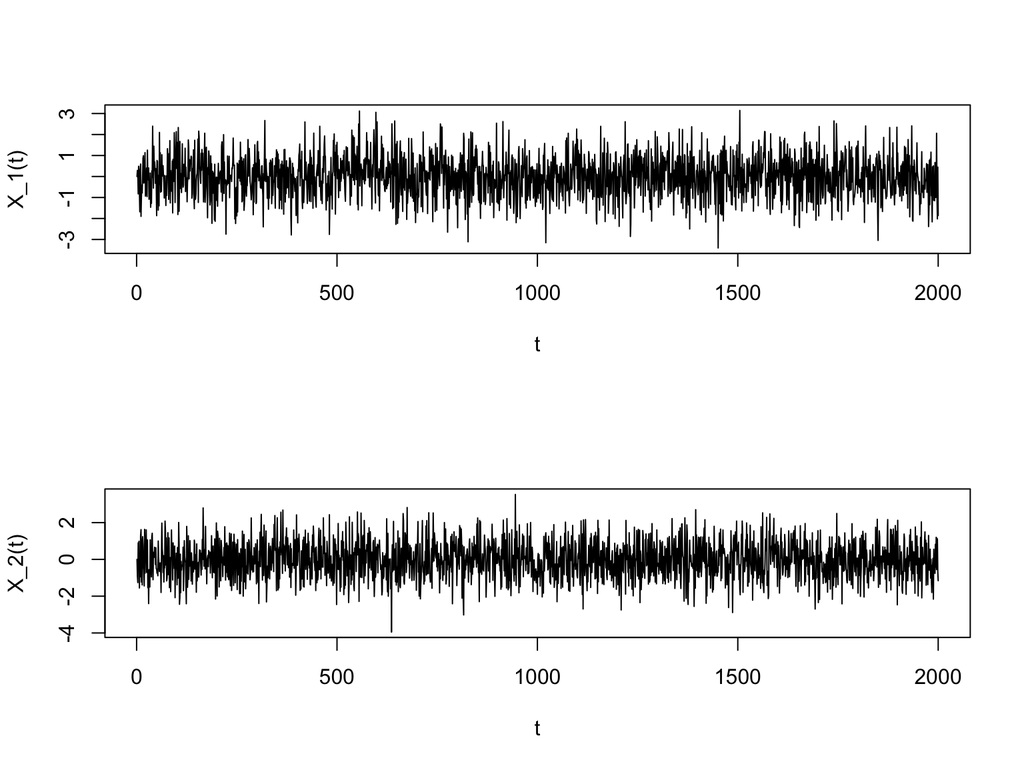

# When $\rho = 0.99$ the sampler is **not** very good!

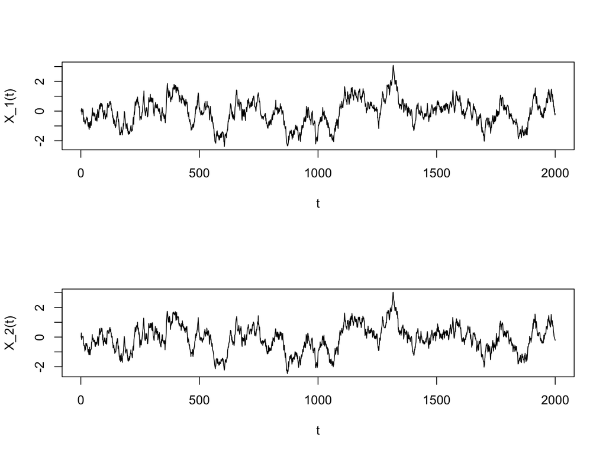

# Gibbs sampler Example 2

- Take the classical Normal-Gamma model
  $$\begin{aligned}
  Y_i|\mu,\tau
  &\sim N(\mu, \tau^{-1}) , \qquad i=1,...,n
  \\
  \mu &\sim N(0, \phi^{-1})
  \\
  \tau &\sim \text{Gamma}(\alpha,\beta)
  \end{aligned}$$
- The priors for $\mu$ and $\tau$ are not conjugate, meaning the posterior $\pi(\mu,\tau|y)$ is not analytically tractable
- The conditional posteriors are however analytically tractable
  $$\begin{aligned}
  \mu | \tau, y &\sim N \left( \frac{\tau}{n\tau + \phi} \sum_{i=1}^n
  y_i, \frac{1}{n\tau + \phi} \right)
  \\
  \tau|\mu,y &\sim \text{Gamma}\left(\alpha + \frac{n}{2}, \beta +
  \frac{1}{2}\sum_{i=1}^n (y_i - \mu)^2 \right)
  \end{aligned}$$

# Gibbs sampler for example 2

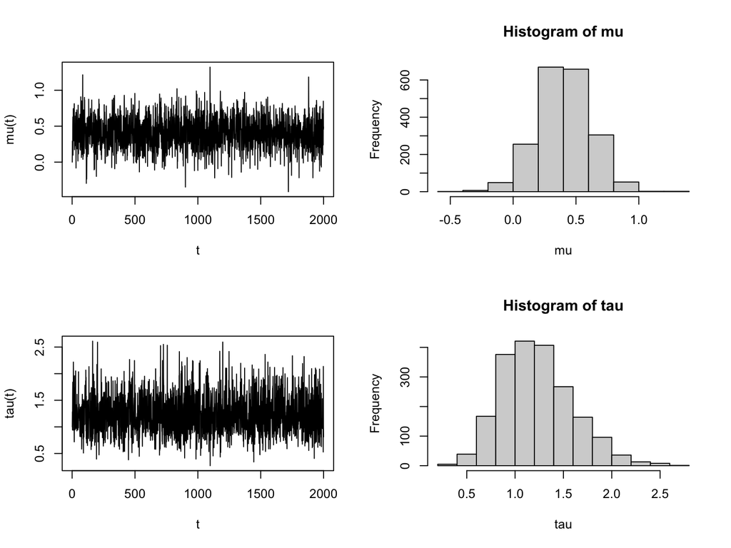

# Remarks on the Gibbs sampler

- PRO: No tuning parameters!
- CON: Not always applicable, as conditionals must be derivable (usually not)
- HISTORY: Until ~2010 probably by far the most popular MCMC algorithm in Bayesian stats!
  - REASON: Conditioning and clever prior choice are skills that Bayesians have
- MODERN DAY: Still very popular, more focus has shifted to other algorithms (e.g. gradient-based)
  - REASON: New generation with more algorithmic approach to problems (less scared of tuning, more scared of problem specific approaches)

# Part 4: A case study

# A case study: Poisson regression

$$\begin{aligned}
Y_i &\sim \text{Poisson}(e^{\sum_{j=1}^d \beta_jx_{ij}}), \\
\beta_j &\stackrel{iid}{\sim} N(0, 1^2).
\end{aligned}$$

There are many types of data and phenomena for which this kind of probabilistic model will be appropriate, so feel free to impose that of most interest to you onto the problem!

# Remarks on the model

- We have imposed $N(0,1^2)$ independent priors for each $\beta_j$
- This will *shrink* the $\beta_j$’s towards zero
- But is it the right amount of shrinkage?
- **To interpret parameters let’s think.** If $x_{ij,\text{new}} = x_{ij,\text{old}}+1$, then
  $$\mu_{i,\text{new}} = e^{\beta_j} \times \mu_{i,\text{old}}$$
- Prior therefore ensures that *plausible* changes are a factor of between $e^{-2}$ and $e^2$.
- Whether or not this is sensible of course depends on your particular setting
- Common alternative: $\beta_j \stackrel{iid}{\sim} N(0,\sigma^2)$ with hyperprior on $\sigma^2$

# Step 1: simulate some data (so we know the truth)

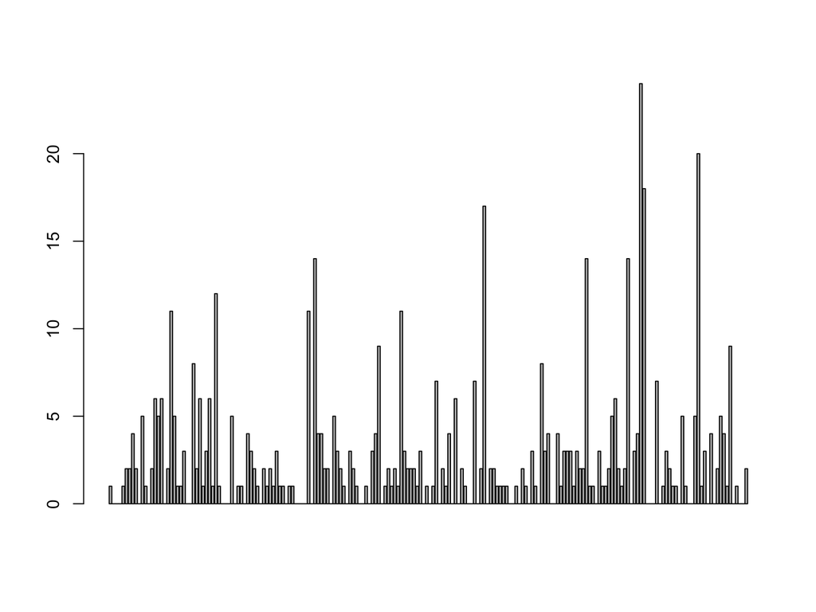

# The (unnormalised) posterior distribution

$$\begin{aligned}
\pi(\beta|y)
&\propto
\prod_i \frac{(e^{\sum_j \beta_j x_{ij}})^{y_i} e^{-e^{\sum_j \beta_j
x_{ij}}}}{y_i!} \prod_j \frac{1}{\sqrt{2\pi}}e^{ -\beta_j^2/2 } \\
& \propto \exp \left( \sum_{i,j} \beta_j x_{ij}y_i - e^{\sum_{i,j}
\beta_j x_{ij} } - \frac{1}{2} \sum_j \beta_j^2 \right).
\end{aligned}$$

# Random Walk Metropolis output

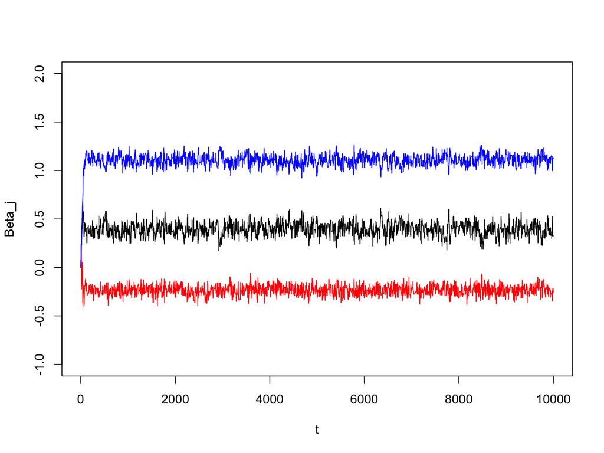

```
## The acceptance rate is:  0.2546
```

# Marginal posterior histograms

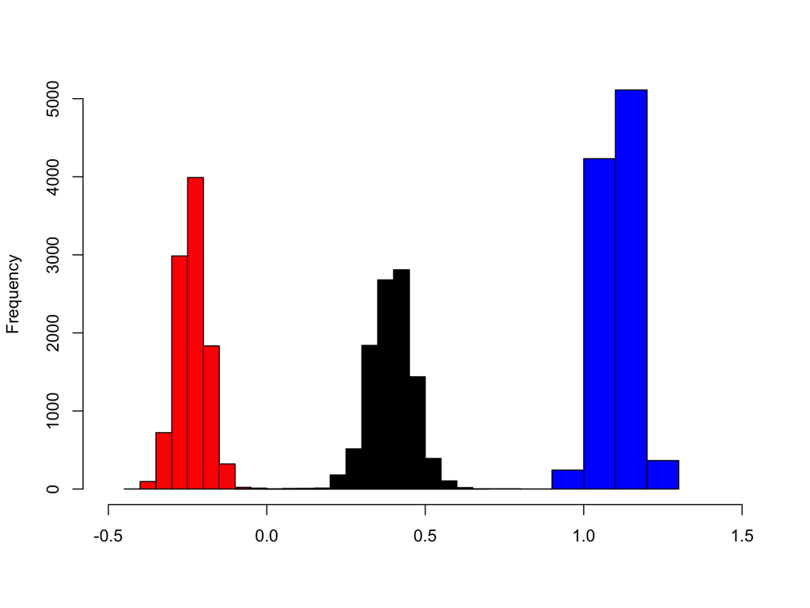

# Further comments

```r
colMeans(mc2$x_store)
```

```
## [1]  0.3944325 -0.2350571  1.1027465
```

- The truth is $\beta_0 = (0.5, -0.25, 1)$
- **Questions.** *Do these estimates make sense?*